# Preliminary Statistical Testing of SPFL Dataset

2026-06-06

# 1 Introduction

This R Markdown file contains preliminary statistical testing for the SPFL 2025/26 dataset. The tests use methods from statistical inference, including binomial tests, paired t-tests, Welch two-sample t-tests, linear regression, multiple regression, and logistic regression.

The aim is to explore whether there is evidence of home advantage, whether attendance and travel distance are associated with home wins, and whether disciplinary patterns differ between home and away teams.

# 2 Load packages and datasets

```r
library(readxl) # Import Excel files into R

spfl <- read_excel("SPFL 2025-2026 Dataset.xlsx", sheet = "SPFL Dataset")
spfl_2020 <- read_excel("SPFL_2020_2021_results.xlsx", sheet = "SPFL 2020-2021")
```

# 3 Binomial test: are home wins more common than 50%?

A binomial test was used to test whether the proportion of home wins was significantly greater than 0.5. The null hypothesis was that home wins and non-home-wins were equally likely.

```r
home_wins <- sum(spfl$Result == "Home", na.rm = TRUE)
n_matches <- sum(!is.na(spfl$Result))

home_wins
```

```
## [1] 102
```

```r
n_matches
```

```
## [1] 228
```

```r
p_value <- sum(dbinom(home_wins:n_matches, n_matches, 0.5))
p_value
```

```
## [1] 0.951212
```

The p-value was approximately 0.95, which is greater than 0.05. Therefore, the null hypothesis cannot be rejected. There is insufficient evidence to suggest that home wins were more likely than non-home wins.

# 4 Paired t-test: do home teams score more goals than away teams?

A paired t-test was used because each match contains a home-goal value and an away-goal value.

```r
t.test(spfl$`Home Goals`,
       spfl$`Away Goals`,
       paired = TRUE,
       alternative = "greater")
```

```
##
##  Paired t-test
##
## data:  spfl$`Home Goals` and spfl$`Away Goals`
## t = 3.5103, df = 227, p-value = 0.0002699
## alternative hypothesis: true mean difference is greater than 0
## 95 percent confidence interval:
##  0.2090124       Inf
## sample estimates:
## mean difference
##       0.3947368
```

The p-value was 0.0002699, which is less than 0.05. Therefore, there is sufficient evidence to suggest that home teams scored more goals than away teams.

# 5 Attendance and match outcome

## 5.1 Attendance in home wins compared with away wins

```r
home_win_attendance <- spfl$Attendance[spfl$Result == "Home"]
away_win_attendance <- spfl$Attendance[spfl$Result == "Away"]

t.test(home_win_attendance, away_win_attendance)
```

```
##
##  Welch Two Sample t-test
##
## data:  home_win_attendance and away_win_attendance
## t = 3.4345, df = 162.99, p-value = 0.000753
## alternative hypothesis: true difference in means is not equal to 0
## 95 percent confidence interval:
##   3818.266 14147.578
## sample estimates:
## mean of x mean of y
##  22724.46  13741.54
```

The p-value was 0.000753, which suggests statistically significant evidence that matches won by the home team had higher attendances than matches won by the away team.

The mean attendances were:

```r
mean(home_win_attendance, na.rm = TRUE)
```

```
## [1] 22724.46
```

```r
mean(away_win_attendance, na.rm = TRUE)
```

```
## [1] 13741.54
```

The mean home-win attendance was approximately 22,724.46, while the mean away-win attendance was approximately 13,741.54.

## 5.2 Percent capacity in home wins compared with away wins

```r
home_win_capacity <- spfl$`Percent Capacity`[spfl$Result == "Home"]
away_win_capacity <- spfl$`Percent Capacity`[spfl$Result == "Away"]

t.test(home_win_capacity, away_win_capacity)
```

```
##
##  Welch Two Sample t-test
##
## data:  home_win_capacity and away_win_capacity
## t = 1.2736, df = 130.27, p-value = 0.2051
## alternative hypothesis: true difference in means is not equal to 0
## 95 percent confidence interval:
##  -0.02470251  0.11398274
## sample estimates:
## mean of x mean of y
## 0.8029243 0.7582841
```

The p-value was 0.2051, which is greater than 0.05. Therefore, there is insufficient evidence to say that percent capacity differs significantly between home wins and away wins.

The mean percent capacities were:

```r
mean(home_win_capacity, na.rm = TRUE)
```

```
## [1] 0.8029243
```

```r
mean(away_win_capacity, na.rm = TRUE)
```

```
## [1] 0.7582841
```

The mean home-win capacity was approximately 0.8029, while the mean away-win capacity was approximately 0.7583.

# 6 Linear regression: is travel distance associated with home wins?

A binary variable was created where a home win was coded as 1 and all other results were coded as 0.

```r
spfl$HomeWin <- ifelse(spfl$Result == "Home", 1,
                       ifelse(spfl$Result %in% c("Away", "Draw"), 0, NA))
```

```r
plot(spfl$`Travel Distance for Away Team`,
     spfl$HomeWin,
     xlab = "Travel Distance for Away Team",
     ylab = "Home Win: 1 = Yes, 0 = No")

travel_lm <- glm(HomeWin ~ `Travel Distance for Away Team`, data = spfl)
summary(travel_lm)
```

```
##
## Call:
## glm(formula = HomeWin ~ `Travel Distance for Away Team`, data = spfl)
##
## Coefficients:
##                                  Estimate Std. Error t value Pr(>|t|)
## (Intercept)                     0.3837505  0.0581367   6.601 2.88e-10 ***
## `Travel Distance for Away Team` 0.0010517  0.0007918   1.328    0.185
## ---
## Signif. codes:  0 '***' 0.001 '**' 0.01 '*' 0.05 '.' 0.1 ' ' 1
##
## (Dispersion parameter for gaussian family taken to be 0.2474861)
##
##     Null deviance: 56.368  on 227  degrees of freedom
## Residual deviance: 55.932  on 226  degrees of freedom
## AIC: 332.65
##
## Number of Fisher Scoring iterations: 2
```

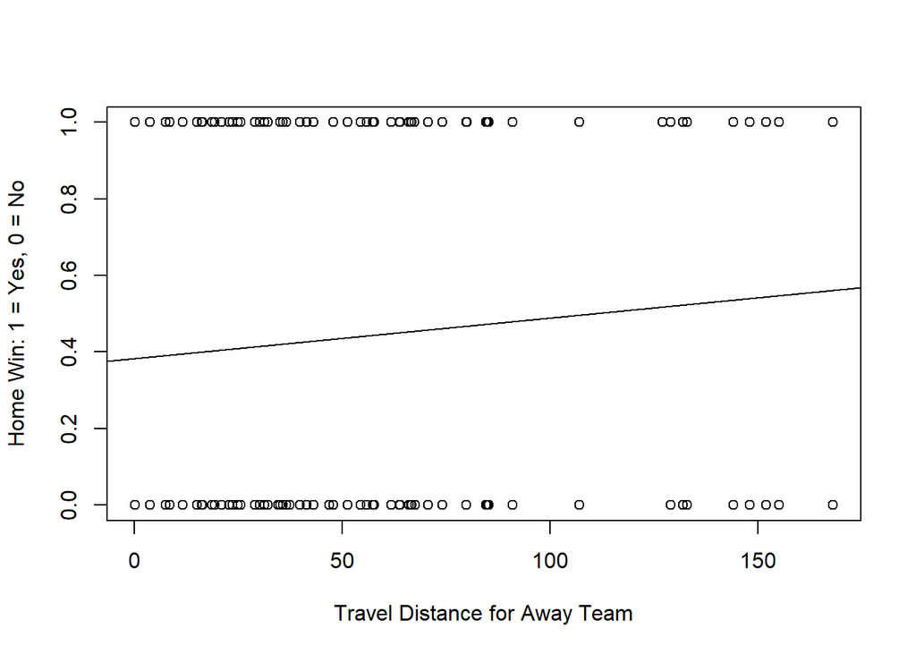

```r
abline(travel_lm)
```

Travel distance had a positive coefficient, meaning that longer away-team travel distance was associated with a slightly higher predicted probability of a home win. However, the p-value was 0.185, which is greater than 0.05, so this relationship was not statistically significant.

# 7 Multiple regression: attendance and travel distance together

```r
multiple_lm <- glm(HomeWin ~ Attendance + `Travel Distance for Away Team`,
                  data = spfl)

summary(multiple_lm)
```

```
##
## Call:
## glm(formula = HomeWin ~ Attendance + `Travel Distance for Away Team`,
##     data = spfl)
##
## Coefficients:
##                                  Estimate Std. Error t value Pr(>|t|)
## (Intercept)                     2.171e-01  6.885e-02   3.154  0.00183 **
## Attendance                      7.822e-06  1.872e-06   4.179 4.19e-05 ***
## `Travel Distance for Away Team` 1.491e-03  7.717e-04   1.932  0.05456 .
## ---
## Signif. codes:  0 '***' 0.001 '**' 0.01 '*' 0.05 '.' 0.1 ' ' 1
##
## (Dispersion parameter for gaussian family taken to be 0.230681)
##
##     Null deviance: 56.368  on 227  degrees of freedom
## Residual deviance: 51.903  on 225  degrees of freedom
## AIC: 317.6
##
## Number of Fisher Scoring iterations: 2
```

The attendance coefficient was approximately 7.822e-06. This means that each additional spectator was associated with an increase of about 0.000007822 in the predicted probability of a home win. Although this sounds small, an extra 10,000 spectators is associated with about a 7.8 percentage point increase in the predicted probability of a home win.

# 8 Logistic regression: do capacity and distance affect the probability of a home win?

A logistic regression model was fitted because `HomeWin` is a binary response variable. The generalised linear model keeps predicted probabilities between 0 and 1.

```r
logit_model <- glm(HomeWin ~ `Percent Capacity` + `Travel Distance for Away Team`,
                   data = spfl,
                   family = "binomial")

summary(logit_model)
```

```
##
## Call:
## glm(formula = HomeWin ~ `Percent Capacity` + `Travel Distance for Away Team`,
##     family = "binomial", data = spfl)
##
## Coefficients:
##                                  Estimate Std. Error z value Pr(>|z|)
## (Intercept)                     -1.521117   0.592337  -2.568   0.0102 *
## `Percent Capacity`               1.247807   0.636133   1.962   0.0498 *
## `Travel Distance for Away Team`  0.005562   0.003317   1.677   0.0936 .
## ---
## Signif. codes:  0 '***' 0.001 '**' 0.01 '*' 0.05 '.' 0.1 ' ' 1
##
## (Dispersion parameter for binomial family taken to be 1)
##
##     Null deviance: 313.54  on 227  degrees of freedom
## Residual deviance: 307.78  on 225  degrees of freedom
## AIC: 313.78
##
## Number of Fisher Scoring iterations: 4
```

Travel distance was also positive, with beta = 0.00556, but was not statistically significant at the 5% level, p = 0.0936.

# 9 Disciplinary analysis: did away teams receive more cards?

## 9.1 Yellow cards

```r
t.test(spfl$`Away Yellow Cards`,
       spfl$`Home Yellow cards`,
       paired = TRUE,
       alternative = "greater")
```

```
##
##  Paired t-test
##
## data:  spfl$`Away Yellow Cards` and spfl$`Home Yellow cards`
## t = 2.9709, df = 227, p-value = 0.001644
## alternative hypothesis: true mean difference is greater than 0
## 95 percent confidence interval:
##  0.1558162       Inf
## sample estimates:
## mean difference
##       0.3508772
```

The p-value was 0.001644, which is below 0.05. Therefore, the null hypothesis is rejected. There is statistically significant evidence that away teams received more yellow cards than home teams.

## 9.2 Red cards

```r
t.test(spfl$`Away Red cards`,
       spfl$`Home Red cards`,
       paired = TRUE,
       alternative = "greater")
```

```
##
##  Paired t-test
##
## data:  spfl$`Away Red cards` and spfl$`Home Red cards`
## t = -0.80001, df = 227, p-value = 0.7877
## alternative hypothesis: true mean difference is greater than 0
## 95 percent confidence interval:
##  -0.0672033        Inf
## sample estimates:
## mean difference
##     -0.02192982
```

The p-value was 0.7877, so the null hypothesis cannot be rejected. There is insufficient evidence that away teams received more red cards than home teams.

# 10 Team-specific card analysis

The following tests compare total cards received at home and away for the top three teams in the league.

## 10.1 Rangers

```r
team <- "Rangers"

home_cards <- spfl$`Home Yellow cards`[spfl$`Home Team` == team] +
  spfl$`Home Red cards`[spfl$`Home Team` == team]

away_cards <- spfl$`Away Yellow Cards`[spfl$`Away Team` == team] +
  spfl$`Away Red cards`[spfl$`Away Team` == team]

mean(home_cards, na.rm = TRUE)
```

```
## [1] 1.473684
```

```r
mean(away_cards, na.rm = TRUE)
```

```
## [1] 2.421053
```

```r
t.test(away_cards, home_cards, alternative = "greater")
```

```
##
##  Welch Two Sample t-test
##
## data:  away_cards and home_cards
## t = 2.3545, df = 35.597, p-value = 0.01209
## alternative hypothesis: true difference in means is greater than 0
## 95 percent confidence interval:
##  0.2678565       Inf
## sample estimates:
## mean of x mean of y
##  2.421053  1.473684
```

For Rangers, the p-value was 0.01209, which is below 0.05. Therefore, there is statistically significant evidence that Rangers received more cards away from home than at home.

## 10.2 Celtic

```r
team <- "Celtic"

home_cards <- spfl$`Home Yellow cards`[spfl$`Home Team` == team] +
  spfl$`Home Red cards`[spfl$`Home Team` == team]

away_cards <- spfl$`Away Yellow Cards`[spfl$`Away Team` == team] +
  spfl$`Away Red cards`[spfl$`Away Team` == team]

mean(home_cards, na.rm = TRUE)
```

```
## [1] 2
```

```r
mean(away_cards, na.rm = TRUE)
```

```
## [1] 2.210526
```

```r
t.test(away_cards, home_cards, alternative = "greater")
```

```
##
##  Welch Two Sample t-test
##
## data:  away_cards and home_cards
## t = 0.37966, df = 35.621, p-value = 0.3532
## alternative hypothesis: true difference in means is greater than 0
## 95 percent confidence interval:
##  -0.7259113        Inf
## sample estimates:
## mean of x mean of y
##  2.210526  2.000000
```

For Celtic, the p-value was 0.3532, which is greater than 0.05. Therefore, there is insufficient evidence that Celtic received more cards away from home than at home.

## 10.3 Hearts

```r
team <- "Hearts"

home_cards <- spfl$`Home Yellow cards`[spfl$`Home Team` == team] +
  spfl$`Home Red cards`[spfl$`Home Team` == team]

away_cards <- spfl$`Away Yellow Cards`[spfl$`Away Team` == team] +
  spfl$`Away Red cards`[spfl$`Away Team` == team]

mean(home_cards, na.rm = TRUE)
```

```
## [1] 1.578947
```

```r
mean(away_cards, na.rm = TRUE)
```

```
## [1] 2.315789
```

```r
t.test(away_cards, home_cards, alternative = "greater")
```

```
##
##  Welch Two Sample t-test
##
## data:  away_cards and home_cards
## t = 1.9519, df = 35.692, p-value = 0.02941
## alternative hypothesis: true difference in means is greater than 0
## 95 percent confidence interval:
##  0.09936645        Inf
## sample estimates:
## mean of x mean of y
##  2.315789  1.578947
```

For Hearts, the p-value was 0.02941, which is below 0.05. Therefore, there is statistically significant evidence that Hearts received more cards away from home than at home.

# 11 Comparing 2025/26 with the 2020/21 COVID season

The 2020/21 season was affected by COVID restrictions, meaning crowds were absent or heavily restricted for much of the season. This section compares disciplinary differences between the two seasons.

```r
names(spfl)
```

```
##  [1] "Date"                              "Home Team"
##  [3] "Away Team"                         "Home Goals"
##  [5] "Away Goals"                        "Result"
##  [7] "Attendance"                        "Percent Capacity"
##  [9] "Travel Distance for Away Team"     "Travel time for Away Team"
## [11] "SPFL team"                         "Stadium Capacity"
## [13] "Team A"                            "Team B"
## [15] "Distance via time Travelled (hrs)" "Distance between A and B (miles)"
## [17] "Goal Difference"                   "Home Red cards"
## [19] "Home Yellow cards"                 "Away Red cards"
## [21] "Away Yellow Cards"                 "HomeWin"
```

```r
names(spfl_2020)
```

```
##  [1] "Date"              "Home Team"         "Away Team"
##  [4] "Home Goals"        "Away Goals"        "Result"
##  [7] "Goal Difference"   "Home Yellow cards" "Home Red cards"
## [10] "Away Yellow cards" "Away Red cards"
```

## 11.1 Total card difference

The card difference is defined as:

$$\text{Card Difference} = \text{Away Cards} - \text{Home Cards}$$

```r
# 2025/26 total card difference
spfl$CardDifference <- (spfl$`Away Yellow Cards` + spfl$`Away Red cards`) -
  (spfl$`Home Yellow cards` + spfl$`Home Red cards`)

# 2020/21 total card difference
spfl_2020$CardDifference <- (spfl_2020$`Away Yellow cards` + spfl_2020$`Away Red cards`) -
  (spfl_2020$`Home Yellow cards` + spfl_2020$`Home Red cards`)

mean(spfl$CardDifference, na.rm = TRUE)
```

```
## [1] 0.3289474
```

```r
mean(spfl_2020$CardDifference, na.rm = TRUE)
```

```
## [1] -0.004385965
```

```r
t.test(spfl$CardDifference,
       spfl_2020$CardDifference,
       alternative = "greater")
```

```
##
##  Welch Two Sample t-test
##
## data:  spfl$CardDifference and spfl_2020$CardDifference
## t = 1.8628, df = 452.7, p-value = 0.03157
## alternative hypothesis: true difference in means is greater than 0
## 95 percent confidence interval:
##  0.03838882        Inf
## sample estimates:
##    mean of x    mean of y
##  0.328947368 -0.004385965
```

The p-value was 0.03157. In 2025/26, away teams received about 0.33 more cards than home teams per match on average. In 2020/21, the difference was almost zero. This suggests that the disciplinary gap between away and home teams was larger in 2025/26.

There is statistically significant evidence that away teams received more cards relative to home teams in the 2025/26 season than in the 2020/21 season. This may provide evidence of home advantage when fans are present in the stadium.

# 12 Rangers home dominance: 2025/26 compared with 2020/21

Rangers had the highest percent capacity in 2025/26. This section tests whether Rangers were more dominant at home without crowds in 2020/21.

```r
rangers_2025_home <- spfl[spfl$`Home Team` == "Rangers", ]
rangers_2020_home <- spfl_2020[spfl_2020$`Home Team` == "Rangers", ]
```

## 12.1 Rangers home win rate

```r
rangers_2025_home$HomeWin <- ifelse(rangers_2025_home$Result == "Home", 1,
                                    ifelse(rangers_2025_home$Result %in% c("Away", "Draw"), 0, NA))

rangers_2020_home$HomeWin <- ifelse(rangers_2020_home$Result == "Home", 1,
                                    ifelse(rangers_2020_home$Result %in% c("Away", "Draw"), 0, NA))

mean(rangers_2025_home$HomeWin, na.rm = TRUE)
```

```
## [1] 0.5789474
```

```r
mean(rangers_2020_home$HomeWin, na.rm = TRUE)
```

```
## [1] 1
```

Rangers won approximately 58% of their home games in 2025/26 compared with 100% in 2020/21.

```r
t.test(rangers_2020_home$HomeWin,
       rangers_2025_home$HomeWin,
       alternative = "greater")
```

```
##
##  Welch Two Sample t-test
##
## data:  rangers_2020_home$HomeWin and rangers_2025_home$HomeWin
## t = 3.6181, df = 18, p-value = 0.0009831
## alternative hypothesis: true difference in means is greater than 0
## 95 percent confidence interval:
##  0.2192548       Inf
## sample estimates:
## mean of x mean of y
## 1.0000000 0.5789474
```

The p-value was 0.0009831, which is below 0.05. Therefore, there is significant evidence that Rangers’ home win rate in 2020/21 was superior to their 2025/26 home win rate.

## 12.2 Rangers home goal difference

Home goal difference is defined as:

$$\text{Home Goal Difference} = \text{Home Goals} - \text{Away Goals}$$

```r
rangers_2025_home$HomeGoalDifference <- rangers_2025_home$`Home Goals` - rangers_2025_home$`Away Goals`
rangers_2020_home$HomeGoalDifference <- rangers_2020_home$`Home Goals` - rangers_2020_home$`Away Goals`

mean(rangers_2025_home$HomeGoalDifference, na.rm = TRUE)
```

```
## [1] 0.9473684
```

```r
mean(rangers_2020_home$HomeGoalDifference, na.rm = TRUE)
```

```
## [1] 2.789474
```

```r
t.test(rangers_2020_home$HomeGoalDifference,
       rangers_2025_home$HomeGoalDifference,
       alternative = "greater")
```

```
##
##  Welch Two Sample t-test
##
## data:  rangers_2020_home$HomeGoalDifference and rangers_2025_home$HomeGoalDifference
## t = 3.4394, df = 35.451, p-value = 0.0007542
## alternative hypothesis: true difference in means is greater than 0
## 95 percent confidence interval:
##  0.9374985       Inf
## sample estimates:
## mean of x mean of y
## 2.7894737 0.9473684
```

Rangers had a mean home goal difference of 2.79 in 2020/21, compared with 0.95 in 2025/26. The p-value was 0.0007542. Therefore, there is statistically significant evidence that Rangers were more dominant at home in the 2020/21 COVID season.